# Iris Dataset

2024-02-15

# Question 1

a.) The variables are: sepal length and width and petal length and width and species. For the 10th sample, the Sepal length is 4.9, Sepal width is 3.1, Petal length is 1.5, Petal Width is 0.1, and the Species is Setosa.

```r
iris[10,]
```

```
##    Sepal.Length Sepal.Width Petal.Length Petal.Width Species
## 10          4.9         3.1          1.5         0.1  setosa
```

b.) There are 150 samples in this dataset. The different species that were measured are: Setosa, Versicolor, and Virginica.

```r
#num of samples
num_rows = nrow(iris)
num_rows
```

```
## [1] 150
```

```r
#num of species
unique(iris$Species)
```

```
## [1] setosa     versicolor virginica
## Levels: setosa versicolor virginica
```

# Question 2

```r
summary(iris)
```

```
##   Sepal.Length    Sepal.Width     Petal.Length    Petal.Width
##  Min.   :4.300   Min.   :2.000   Min.   :1.000   Min.   :0.100
##  1st Qu.:5.100   1st Qu.:2.800   1st Qu.:1.600   1st Qu.:0.300
##  Median :5.800   Median :3.000   Median :4.350   Median :1.300
##  Mean   :5.843   Mean   :3.057   Mean   :3.758   Mean   :1.199
##  3rd Qu.:6.400   3rd Qu.:3.300   3rd Qu.:5.100   3rd Qu.:1.800
##  Max.   :7.900   Max.   :4.400   Max.   :6.900   Max.   :2.500
##        Species
##  setosa    :50
##  versicolor:50
##  virginica :50
##
##
##
```

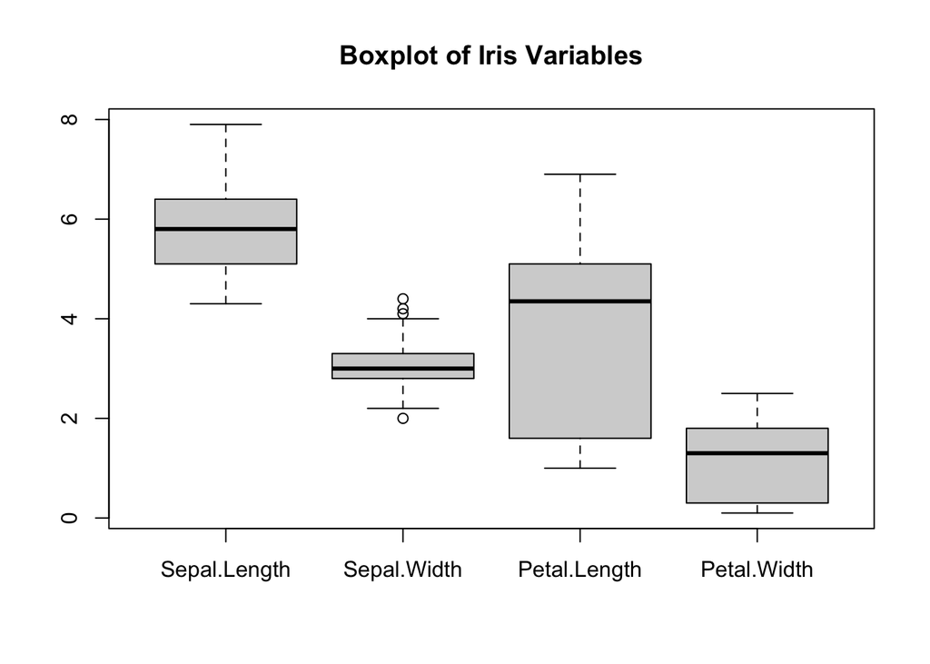

```r
sd_cols = apply(iris[,1:4], 2, sd)
sd_rows = apply(iris[,1:4], 1, sd)
boxplot(iris[, 1:4], main = "Boxplot of Iris Variables")
```

```r
#standard deviation
stdev = sd(iris$Sepal.Length)
stdev
```

```
## [1] 0.8280661
```

```r
#5 num summary
sub_sum = summary(subset_data)
print(sub_sum)
```

```
##   Sepal.Length    Sepal.Width
##  Min.   :4.300   Min.   :3.00
##  1st Qu.:4.850   1st Qu.:3.25
##  Median :5.100   Median :3.70
##  Mean   :5.182   Mean   :3.60
##  3rd Qu.:5.550   3rd Qu.:3.85
##  Max.   :5.800   Max.   :4.40
```

```r
sub_set = iris[10:20, "Sepal.Length"]
standard_deviation = sd(sub_set)
print(standard_deviation)
```

```
## [1] 0.4665151
```

a.) There are 50 observations of each species. b.) Sepal.Length and Sepal.Width have medians smaller than their means. c.) The standard deviation of the sepal length measurements is 0.8280661. d.) The standard deviation of the sepal length measurements of this subset is 0.4665151.

# Question 3

```r
atomic_vec = c(1, 4, 3, 2, NA, 3.22, -44, 2, NA, 0, 22, 34)
```

a.) There are 8 positive numbers in the vector. b.) There is 1 negative number in the vector, c.) There is 1 zero in the vector. d.) There are 2 NAs in the vector. e.) There are 9 non-zero & NA numbers in the vector. f.) The sum of the positive numbers is 71.22. g.) The sum of the negative numbers is -44.

```r
#a
pos_nums = sum(atomic_vec > 0, na.rm = TRUE)
print(pos_nums)
```

```
## [1] 8
```

```r
#b
neg_nums = sum(atomic_vec < 0, na.rm = TRUE)
print(neg_nums)
```

```
## [1] 1
```

```r
#c
zero_nums = sum(atomic_vec == 0, na.rm = TRUE)
print(zero_nums)
```

```
## [1] 1
```

```r
#d
NA_nums = sum(is.na(atomic_vec))
print(NA_nums)
```

```
## [1] 2
```

```r
#e
e = sum(atomic_vec != 0 & !is.na(atomic_vec))
print(e)
```

```
## [1] 9
```

```r
#f
sums_pos = sum(atomic_vec[atomic_vec>0], na.rm = TRUE)
print(sums_pos)
```

```
## [1] 71.22
```

```r
#g
sums_neg = sum(atomic_vec[atomic_vec<0], na.rm = TRUE)
print(sums_neg)
```

```
## [1] -44
```

# Question 4

b.) First 8 entries: 1, 1, 2, 3, 5, 8, 13, 21. Last 8 entries: 1.497069e+207, 2.422308e+207, 3.919377e+207,6.341685e+207, 1.026106e+208, 1.660275e+208, 2.686381e+208, 4.346656e+208.

```r
first = fib_vec[1:8]
print(first)
```

```
## [1]  1  1  2  3  5  8 13 21
```

```r
last = tail(fib_vec,8)
print(last)
```

```
## [1] 1.497069e+207 2.422308e+207 3.919377e+207 6.341685e+207 1.026106e+208
## [6] 1.660275e+208 2.686381e+208 4.346656e+208
```

c.)

```r
z_n = fib_vec[-length(fib_vec)] / fib_vec[-1]
z_n999 = z_n[1:999]
head(z_n999,10)
```

```
##  [1] 1.0000000 0.5000000 0.6666667 0.6000000 0.6250000 0.6153846 0.6190476
##  [8] 0.6176471 0.6181818 0.6179775
```

d.)

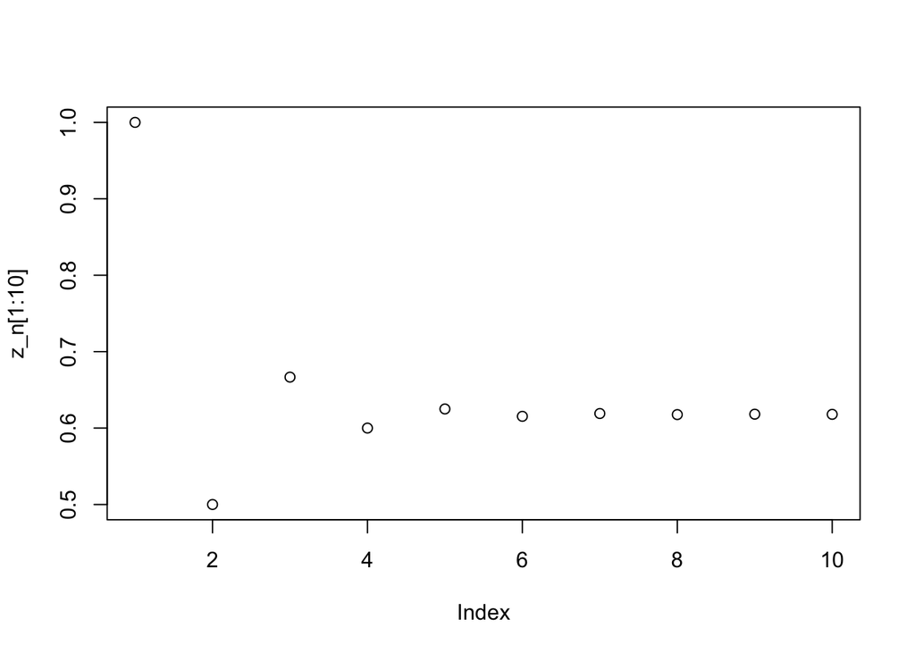

```r
plot(z_n[1:10])
abline(h = (1 + sqrt(5))/2)
```

e.) Initially there is a big change but the values become more stable and similar as the n-value increases.

f.) This code is not meant for vectors. The syntax for vectors would need brackets.

# Question 5

```r
#matrix 1
fib_matrix1 = matrix(fib_vec, nrow = 100, ncol = 10, byrow = TRUE)
#print(fib_matrix1)

#matrix 2
fib_matrix2 = t(fib_matrix1)
#print(fib_matrix2)
```

```r
#array
fib_vector = numeric(100)
fib_vector[1] = 1
fib_vector[2] = 1
for (i in 3:100){
  fib_vector[i] = fib_vector[i-1] + fib_vector[i-2]
}

fib_matrices = array(fib_vector, dim = c(10,10,10))
fib_stacked = apply(fib_matrices, MARGIN = c(1,3), FUN = c)
```

a.) The mean is: 4.816372e+36.

```r
mean_18th = mean(fib_matrix1[18, ])
print(mean_18th)
```

```
## [1] 4.816372e+36
```

b.) The standard deviation is: 7.582333e+15

```r
sd_8th = sd(fib_matrix2[, 8])
print(sd_8th)
```

```
## [1] 7.582333e+15
```

c.) The entry in the 5th row of the 2nd column of the 8th matrix in fib_array is: 610

```r
ans = fib_matrices[5,2,8]
print(ans)
```

```
## [1] 610
```